# K Means Application: Data Science Capstone

### hand selection - 2 dim - 2 clusters

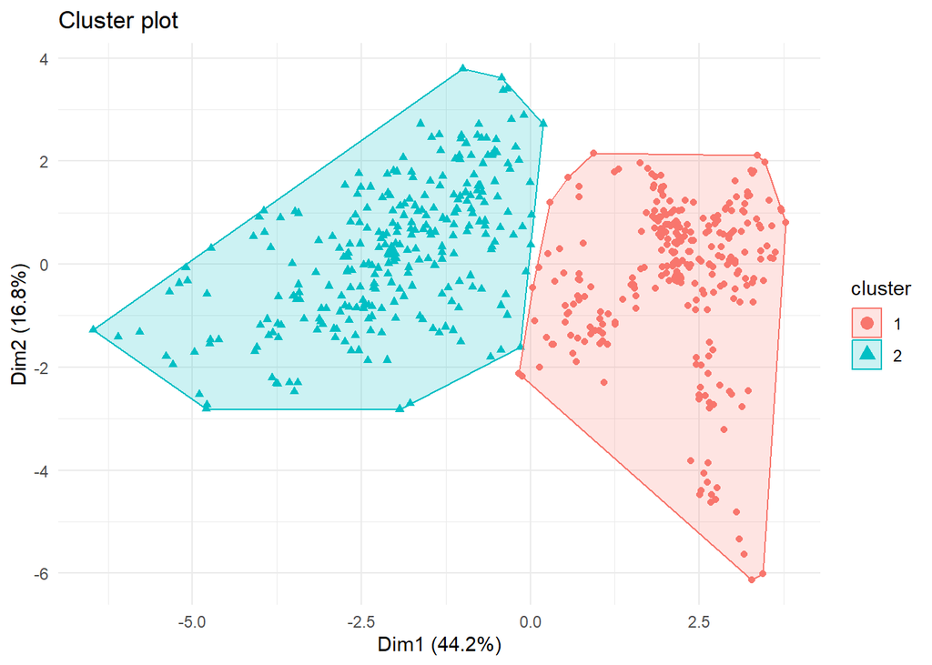

```r
# Choose a feature selection method
# selected_features <- feature_selection_all(data)
 selected_features <- feature_selection_hand(data)
# selected_features <- feature_selection_variance(data, variance_threshold = 1)
# selected_features <- feature_selection_rfe(data)
# selected_features <- feature_selection_lasso(data)

# Run PCA and K-Means
pca_dimensions <- 2
number_of_clusters <- 2
pca_kmeans_result <- run_pca_kmeans(selected_features, pca_dimensions, number_of_clusters)

# Create visualizations
plots <- visualizations(data, selected_features, pca_kmeans_result$pca_data, pca_kmeans_result$kmeans_result, color_palette)

# Display plots
plots$cluster_plot
```

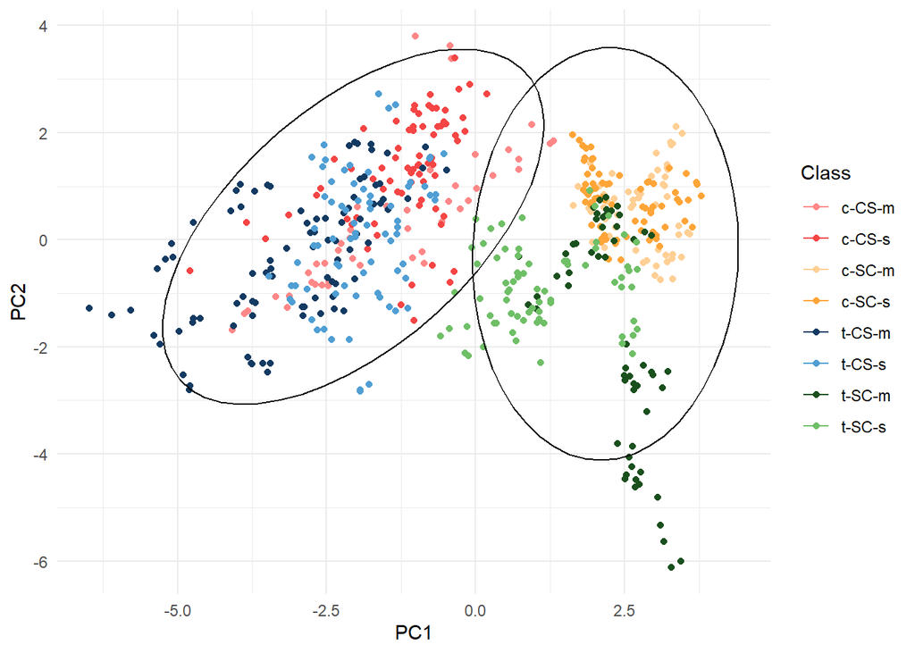

```r
plots$pca_plot
```

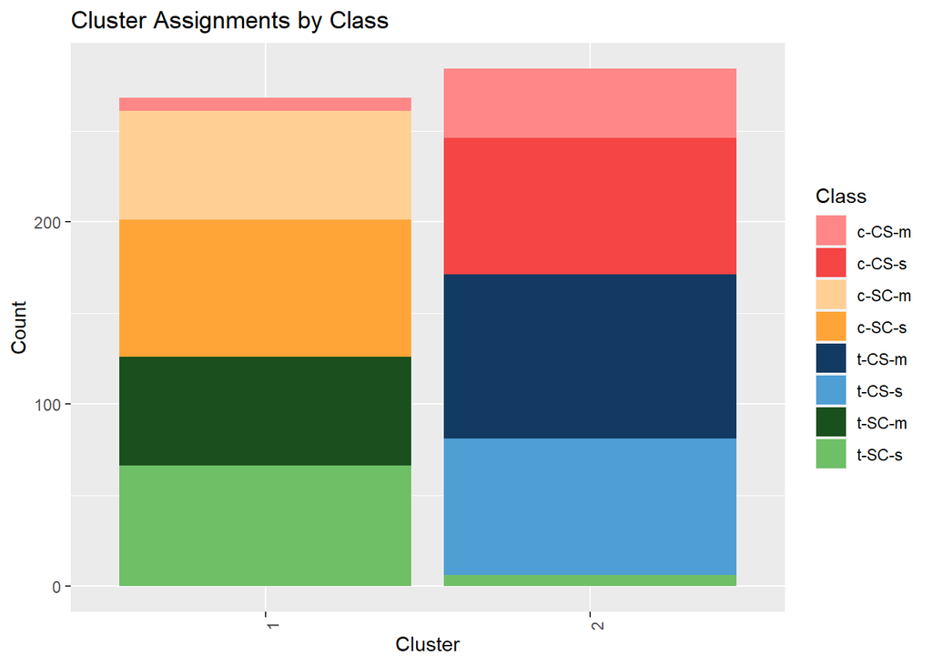

```r
plots$cluster_assignment_plot
```

### hand selection - 2 dim - 4 clusters

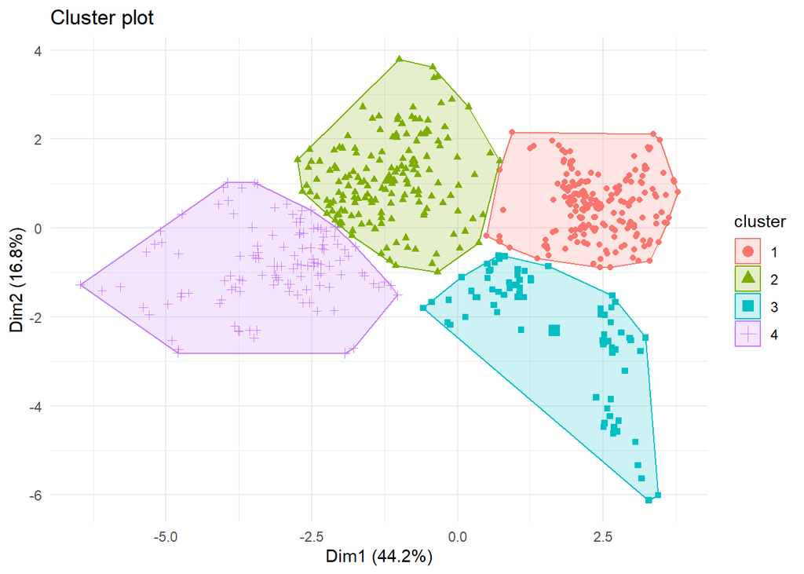

```r
# Choose a feature selection method
# selected_features <- feature_selection_all(data)
 selected_features <- feature_selection_hand(data)
# selected_features <- feature_selection_variance(data, variance_threshold = 1)
# selected_features <- feature_selection_rfe(data)
# selected_features <- feature_selection_lasso(data)

# Run PCA and K-Means
pca_dimensions <- 2
number_of_clusters <- 4
pca_kmeans_result <- run_pca_kmeans(selected_features, pca_dimensions, number_of_clusters)

# Create visualizations
plots <- visualizations(data, selected_features, pca_kmeans_result$pca_data, pca_kmeans_result$kmeans_result, color_palette)

# Display plots
plots$cluster_plot
```

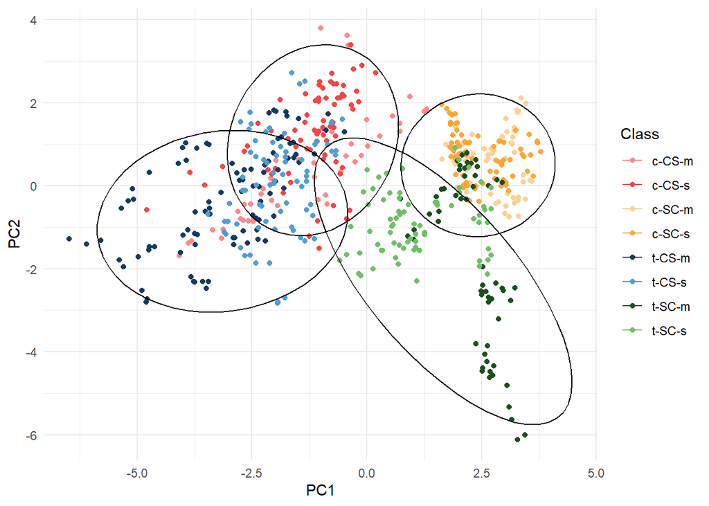

```r
plots$pca_plot
```

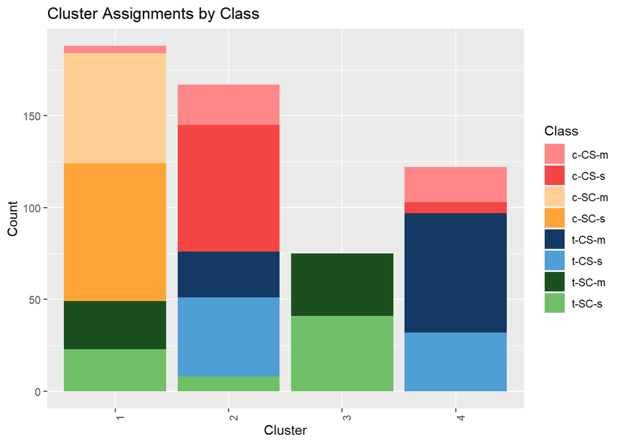

```r
plots$cluster_assignment_plot
```

### hand selection - 2 dim - 6 clusters

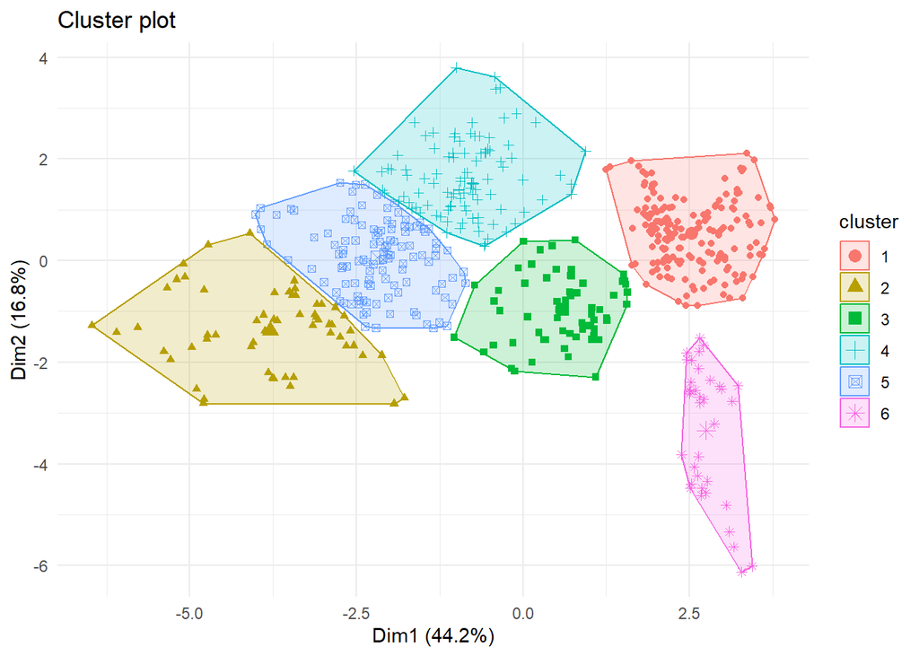

```r
# Choose a feature selection method
# selected_features <- feature_selection_all(data)
 selected_features <- feature_selection_hand(data)
# selected_features <- feature_selection_variance(data, variance_threshold = 1)
# selected_features <- feature_selection_rfe(data)
# selected_features <- feature_selection_lasso(data)

# Run PCA and K-Means
pca_dimensions <- 2
number_of_clusters <- 6
pca_kmeans_result <- run_pca_kmeans(selected_features, pca_dimensions, number_of_clusters)

# Create visualizations
plots <- visualizations(data, selected_features, pca_kmeans_result$pca_data, pca_kmeans_result$kmeans_result, color_palette)

# Display plots
plots$cluster_plot
```

```r
plots$pca_plot
```

[output not shown]

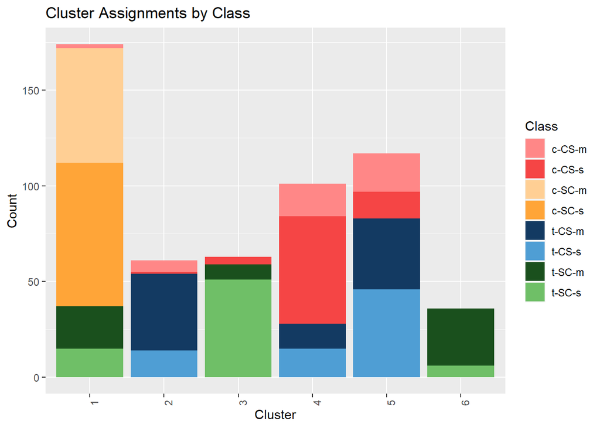

```r
plots$cluster_assignment_plot
```

### hand selection - 2 dim - 8 clusters

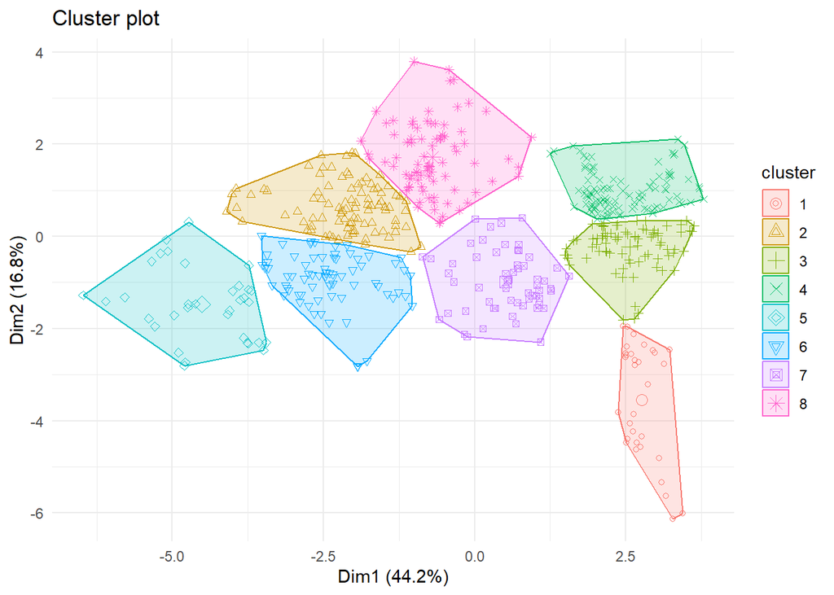

```r
# Choose a feature selection method
# selected_features <- feature_selection_all(data)
 selected_features <- feature_selection_hand(data)
# selected_features <- feature_selection_variance(data, variance_threshold = 1)
# selected_features <- feature_selection_rfe(data)
# selected_features <- feature_selection_lasso(data)

# Run PCA and K-Means
pca_dimensions <- 2
number_of_clusters <- 8
pca_kmeans_result <- run_pca_kmeans(selected_features, pca_dimensions, number_of_clusters)

# Create visualizations
plots <- visualizations(data, selected_features, pca_kmeans_result$pca_data, pca_kmeans_result$kmeans_result, color_palette)

# Display plots
plots$cluster_plot
```

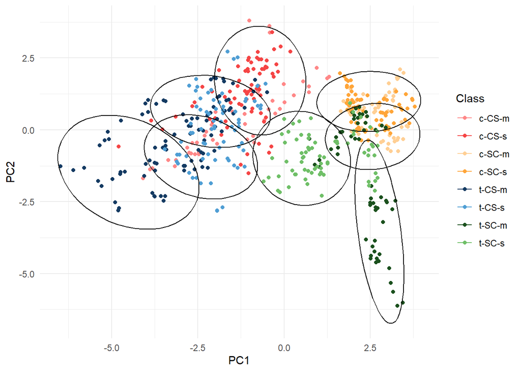

```r
plots$pca_plot
```

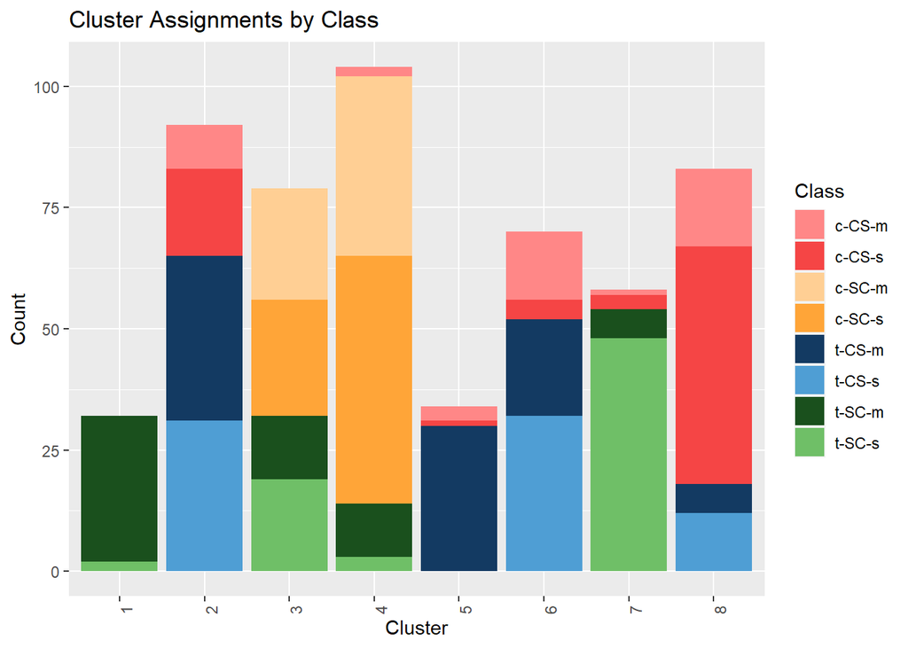

```r
plots$cluster_assignment_plot
```

## Conclusions

Our results indicate that the mice protein expression data set exhibits clusters which largely correspond to the learning and non-learning behavior groups.No such clustering is observed with regard to genotype or treatment group based on the considerations of class composition by cluster. Clustering is a vital data mining process that assists in data analysis by revealing patterns, trends and data associations within a large dataset by forming clusters of similar data points. This technique is used extensively in both research and business to facilitate decisions and address outcomes. By creating group clusters, it simplifies the data interpretation process and allows the detection of anomalies or outliers. Despite its limitations, such as the need of predetermining the number of clusters and the potential to converge to local optima, k-means is still widely used due to its simplicity and versatility.

Techniques and modifications continue to evolve to make k-means even more effective. Researchers are addressing these challenges by enhancing the algorithm’s scalability and robustness. These limitations are being addressed by researchers like Arthur, D et al, by improving the first step of k-means to avoid poor clustering due to random initialization. Yang et al propose a new method on selecting the optimal k value by addressing both application-specific and detector-specific factors. The authors proposed the KFC method which offers a parameter free solution with linear time complexity. Yang et al made the KFC method available at www.outliernet.com to an external site to facilitate reproducibility and provide opportunities for others to expand their research. Their research showed that the KFC method outperforms traditional methods and is much more versatile making it useful across many fields. Guojun Gan and Michael Kwok-Po Ng propose to improve the k-means clustering algorithm by including outlier detection. The KMOR (k-means with outlier removal) algorithm broadens the classic k-means algorithm by proposing an additional cluster for outliers. The methodology comprises initialization, objective function optimization, iterative process updates, convergence, and parameter control. . The KMOR algorithm’s ability to seamlessly integrate clustering and outlier detection for both synthetic and real datasets showcased its dominance over current methods in terms of accuracy and efficiency. Futuristically, the goals are to investigate diverse ways to control outliers by refining parameter selection and broadening the algorithm for subspace clustering (Gan and Ng 2017).

As future improvements are applied, k-means clustering will continue to enhance its utility across various disciplines. It finds extensive applications across multiple domains including data mining, image processing, bioinformatics, public health, market research, anomaly detection and pattern recognition. Each of these applications demonstrates the ability to provide valuable insights and decision making across a wide range of`fields.

## References

Bayat, Ardeshir. 2002. “Bioinformatics.” *BMJ : British Medical Journal* 324 (7344): 1018–22. https://www.ncbi.nlm.nih.gov/pmc/articles/PMC1122955/.

Berkhin, P. 2006. “A Survey of Clustering Data Mining Techniques.” In *Grouping Multidimensional Data: Recent Advances in Clustering*, edited by Jacob Kogan, Charles Nicholas, and Marc Teboulle, 25–71. Berlin, Heidelberg: Springer Berlin Heidelberg. https://doi.org/10.1007/3-540-28349-8_2.

Gan, Guojun, and Michael Kwok-Po Ng. 2017. “*K*-Means Clustering with Outlier Removal.” *Pattern Recognition Letters* 90 (April): 8–14. https://doi.org/10.1016/j.patrec.2017.03.008.

Hastie, Trevor, Robert Tibshirani, and Jerome Friedman. 2009. *The Elements of Statistical Learning, Second Edition : Data Mining, Inference, and Prediction*. 2nd ed. Springer. https://hastie.su.domains/Papers/ESLII.pdf.

Higuera, Clara, Katheleen J. Gardiner, and Krzysztof J. Cios. 2015. “Self-Organizing Feature Maps Identify Proteins Critical to Learning in a Mouse Model of Down Syndrome.” *PLOS ONE* 10 (6): e0129126. https://doi.org/10.1371/journal.pone.0129126.

Ikotun, Abiodun M., Absalom E. Ezugwu, Laith Abualigah, Belal Abuhaija, and Jia Heming. 2023. “K-Means Clustering Algorithms: A Comprehensive Review, Variants Analysis, and Advances in the Era of Big Data.” *Information Sciences* 622 (April): 178–210. https://doi.org/10.1016/j.ins.2022.11.139.

Kodinariya, Trupti M., and Prashant R. Makwana. 2013. “Review on Determining Number of Cluster in k-Means Clustering.” In. https://www.semanticscholar.org/paper/Review-on-determining-number-of-Cluster-in-K-Means-Kodinariya-Makwana/1a34936bffe558a380168b790dc37956813514ba.

Tleis, Malak, Roberta Callieris, and Rocco Roma. 2017. “Segmenting the Organic Food Market in Lebanon: An Application of k-Means Cluster Analysis.” *British Food Journal* 119 (7): 1423–41. https://doi.org/10.1108/BFJ-08-2016-0354.

Zelasky, Sarah, Chantel L. Martin, Christopher Weaver, Lisa K. Baxter, and Kristen M. Rappazzo. 2023. “Identifying Groups of Children’s Social Mobility Opportunity for Public Health Applications Using k-Means Clustering.” *Heliyon* 9 (9): e20250. https://doi.org/10.1016/j.heliyon.2023.e20250.